# Image classification CNN

In this lab we will train a convolution neural network for image classification from scratch. You will implement a CNN, a training and a validation loop, a custom dataset loader and a couple of helper functions.

## Speed and hardware

Image classification CNN training is typically done on GPUs, often multiple ones, as the process is very computationally intensive. This assignment, on the other hand, is created to be run on a CPU: a single training epoch takes 1-5 minutes, depending on the CNN architecture and hardware.

Specifically, it takes 90 sec for training an epoch on the laptop i7 CPU and 26 sec on the mobile GT940M GPU. Another option is to use [Google Colab](https://colab.research.google.com/). In the latter case, you will find comments with additional commands to run. Also, all the data (saved networks, datasets) will be auto-deleted after the end of the runtime session, so make sure to download the results of the training.

```python
# enable saving the weights and other files
from google.colab import drive
drive.mount('/content/drive')
```

```python
# load all necessary files
# !ls "/content/drive/MyDrive/Colab Notebooks/MPV/CNN/"
!cp -r "/content/drive/MyDrive/Colab Notebooks/MPV/CNN/stats.pkl"               "/content/"
!cp -r "/content/drive/MyDrive/Colab Notebooks/MPV/CNN/cnn_training.py"         "/content/"
!cp -r "/content/drive/MyDrive/Colab Notebooks/MPV/CNN/test_set/"               "/content/"
```

```python
# load updated version of cnn_training.py
!cp -r "/content/drive/MyDrive/Colab Notebooks/MPV/CNN/cnn_training.py"         "/content/"
```

```python
# load saved weights from previous trainings
!cp -r "/content/drive/MyDrive/Colab Notebooks/MPV/CNN/weights_vgg16light.pts"  "/content/"    # 500 Mb takes about 1 min
!cp -r "/content/drive/MyDrive/Colab Notebooks/MPV/CNN/weights_Simproved_v2.pts"  "/content/"
```

First, let's download the data.

**Imagenette** is a subset of 10 easily classified classes from Imagenet (tench, English springer, cassette player, chain saw, church, French horn, garbage truck, gas pump, golf ball, parachute).

The subset is created by [Jeremy Howard](https://twitter.com/jeremyphoward) and available at https://github.com/fastai/imagenette

Note: Much faster than coppying from local!

```python
# FOR COLAB: uncomment and run the following code every time you are starting the session
# for local: uncomment and run once
!wget https://s3.amazonaws.com/fast-ai-imageclas/imagenette2-160.tgz
!tar -xzf imagenette2-160.tgz
```

```
--2024-05-03 12:01:03--  https://s3.amazonaws.com/fast-ai-imageclas/imagenette2-160.tgz
Resolving s3.amazonaws.com (s3.amazonaws.com)... 52.216.249.238, 52.216.40.192, 52.216.109.61, ...
Connecting to s3.amazonaws.com (s3.amazonaws.com)|52.216.249.238|:443... connected.
HTTP request sent, awaiting response... 200 OK
Length: 99003388 (94M) [application/x-tar]
Saving to: ‘imagenette2-160.tgz’

imagenette2-160.tgz 100%[===================>]  94.42M  38.1MB/s    in 2.5s

2024-05-03 12:01:06 (38.1 MB/s) - ‘imagenette2-160.tgz’ saved [99003388/99003388]
```

```python
# FOR COLAB: uncomment and run the following code every time you are starting the session
!pip install kornia
```

[output not shown]

```python
%load_ext autoreload
%autoreload 2
%matplotlib inline
import matplotlib.pyplot as plt
import seaborn as sns

import numpy as np
import cv2

import torch
import torch.nn as nn
import torch.nn.functional as F
import torchvision as tv
import kornia as K
from tqdm import tqdm_notebook as tqdm
from time import time

def imshow_torch(tensor,figsize=(8,6), *kwargs):
    plt.figure(figsize=figsize)
    plt.imshow(K.tensor_to_image(tensor), *kwargs)
    return

def imshow_torch_channels(tensor, dim = 1, *kwargs):
    num_ch = tensor.size(dim)
    fig=plt.figure(figsize=(num_ch*5,5))
    tensor_splitted = torch.split(tensor, 1, dim=dim)
    for i in range(num_ch):
        fig.add_subplot(1, num_ch, i+1)
        plt.imshow(K.tensor_to_image(tensor_splitted[i].squeeze(dim)), *kwargs)
    return

from cnn_training import *
```

# Dataset and DataLoader

Now, let's create dataset and data loaders. Dataset is an object, which contains training samples (or can read/generate them on the fly) and all necessary additional information. Data loader is an object, which takes samples from the dataset and generates the batch in efficient way.

For more details, see here https://pytorch.org/docs/stable/data.html and here https://pytorch.org/tutorials/beginner/data_loading_tutorial.html

There are also several classes for the most common use-cases, in torchvision module: https://pytorch.org/docs/stable/torchvision/datasets.html

We will use [ImageFolder](https://pytorch.org/docs/stable/torchvision/datasets.html#imagefolder) class. It assumes that data is already structured like this 'datasetroot/class1/images":

```
root/dog/xxy.jpg
root/dog/xxz.png

root/cat/123.png
root/cat/nsdf3.png
root/cat/asd932_.png
```

We need to specify two input parameters: path to the root directory and transform. Transform takes PIL.Image and outputs torch.tensor. It can also do some data modification: augmentation, normalization and so on. Let's do it on example. We will resize our data to 128x128 px size, transform to tensor and normalize them to have zero mean and unit variance. Your first task is to write function `get_dataset_statistics`, which takes a dataset object and return its mean and std (pixel-wise). Remember, that you have to calculate the statistics **only** on training set, not validation or test sets.

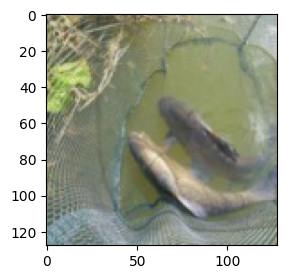

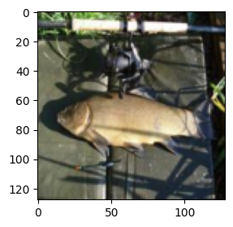

[figure not shown]

```python
import torchvision.transforms as tfms
train_transform = tfms.Compose([tfms.Resize((128,128)),
                                tfms.ToTensor()])


ImageNette_for_statistics = tv.datasets.ImageFolder('imagenette2-160/train',
                                    transform = train_transform)

for i in range(3):
    imshow_torch(ImageNette_for_statistics[i][0], figsize=(3,3))
```

```python
# resolution = 128 # orig res
# resolution = 224
resolution = 512
base_tf = tfms.Compose([tfms.Resize((resolution, resolution)), tfms.ToTensor()])
ImageNette_for_statistics = tv.datasets.ImageFolder('imagenette2-160/train', transform=base_tf)
print("Number of images: ", len(ImageNette_for_statistics))
```

```
Number of images:  9469
```

```python
from cnn_training import get_stats    # wrapper for stats computation

mean, std = get_stats(ImageNette_for_statistics)
print("Mean: ", mean)  # [0.46248055, 0.4579692, 0.42981696]
print("Std: ", std)    # [0.27553096, 0.27220666, 0.295335]
```

```
Loading statistics...
Mean:  [0.4624772071838379, 0.45796748995780945, 0.42980268597602844]
Std:  [0.27531859278678894, 0.27213260531425476, 0.29514896869659424]
```

```python
for data in ImageNette_for_statistics:
    break
print (data[0].shape)
```

```
torch.Size([3, 512, 512])
```

Now lets create the transform and datasets for training, which include [input normalization](https://stats.stackexchange.com/questions/185853/why-do-we-need-to-normalize-the-images-before-we-put-them-into-cnn). To avoid overfitting, we may include slight data augmentation into training transform: random cropping and random horizontal flip.

```python
# include normalisation
train_tf = tfms.Compose([tfms.Resize((resolution, resolution)),
                          tfms.RandomHorizontalFlip(p=0.5),
                          tfms.RandomResizedCrop(size=(resolution, resolution)),
                          tfms.ToTensor(),
                          tfms.Normalize(mean, std)])

val_tf = tfms.Compose([tfms.Resize((resolution, resolution)),
                        tfms.ToTensor(),
                        tfms.Normalize(mean, std)])

ImageNette_train = tv.datasets.ImageFolder('imagenette2-160/train', transform=train_tf)
ImageNette_val = tv.datasets.ImageFolder('imagenette2-160/val', transform=val_tf)
```

Now lets create data loaders. The most important parameters are batch size (number of samples in the mini-batch), number of workers (good idea to match them to number of cores of your CPU or less.

```python
# Taken from here https://stackoverflow.com/a/58748125/1983544
import os
num_workers = os.cpu_count()
if 'sched_getaffinity' in dir(os):
    num_workers = len(os.sched_getaffinity(0)) - 2
print(num_workers)
```

```
14
```

```python
import torch
if torch.cuda.is_available():
    torch.cuda.device_count()
    cur = torch.cuda.current_device()
    print(torch.cuda.get_device_name(cur))
else:
    print("No CUDA device")
```

```
NVIDIA L4
```

On GPU, the bigger batchsize, the more efficient is training. On the other hand, smaller batch_size may lead to better results in terms of final accuracy. The selection of the proper batch size and other parameters depending on it, is an active research area. We will take the batch of 32. Feel free to adjust it according to your hardware and memory amount.

```python
batch_size = 32  # dl. lengths match the number of images in coresp. folders
train_dl = torch.utils.data.DataLoader(ImageNette_train,
                                        batch_size= batch_size,
                                        shuffle = True, # important thing to do for training.
                                        num_workers = num_workers)
val_dl = torch.utils.data.DataLoader(ImageNette_val,
                                      batch_size= batch_size,
                                      shuffle = False,
                                      num_workers = num_workers,
                                      drop_last=False)  # do not drop the last (smaller) batch for validation
```

```python
# batch.shape: [batch_size, 3, resolution, resolution]
for data, labels in train_dl:
    break
print (data.shape, labels.shape)
```

```
torch.Size([32, 3, 512, 512]) torch.Size([32])
```

```
for data, labels in train_dl:
    break
print (data.shape, labels.shape)
```

[output not shown]

Now, lets define a model. It should consist of convolution, non-linearity, pooling, batch-norm layers. And finish with a classifier. It is your task to experiment and find a good model. We will show VGG-style model.

Papers to look for inspiration:

- [AlexNet](https://papers.nips.cc/paper/4824-imagenet-classification-with-deep-convolutional-neural-networks.pdf)
- [VGGNet](https://arxiv.org/pdf/1409.1556)
- [Systematic Evaluation of Convolution Neural Network Advances on the ImageNet](https://arxiv.org/pdf/1606.02228).
- [ResNet](https://arxiv.org/abs/1512.03385)
- [Bag of tricks](https://arxiv.org/abs/1812.01187)
- [Compounding the Performance Improvements of Assembled Techniques in a Convolutional Neural Network](https://arxiv.org/pdf/2001.06268.pdf)

But remember that models above are quite beefy, so one may need something lighter for the current task.

**Important: you need to define your own model, the default one is not enough to pass the assignment**

```python
from cnn_training import SimpleCNN_improved

num_classes = len(ImageNette_train.classes)
model = SimpleCNN_improved(num_classes)

print(model)
```

```
SimpleCNN_improved(
  (features): Sequential(
    (0): Conv2d(3, 32, kernel_size=(7, 7), stride=(2, 2), padding=(3, 3), bias=False)
    (1): BatchNorm2d(32, eps=1e-05, momentum=0.1, affine=True, track_running_stats=True)
    (2): ReLU(inplace=True)
    (3): MaxPool2d(kernel_size=2, stride=2, padding=0, dilation=1, ceil_mode=False)
    (4): Conv2d(32, 64, kernel_size=(5, 5), stride=(2, 2), padding=(2, 2), bias=False)
    (5): BatchNorm2d(64, eps=1e-05, momentum=0.1, affine=True, track_running_stats=True)
    (6): ReLU(inplace=True)
    (7): Conv2d(64, 64, kernel_size=(5, 5), stride=(2, 2), padding=(2, 2), bias=False)
    (8): BatchNorm2d(64, eps=1e-05, momentum=0.1, affine=True, track_running_stats=True)
    (9): ReLU(inplace=True)
    (10): MaxPool2d(kernel_size=2, stride=2, padding=0, dilation=1, ceil_mode=False)
    (11): Conv2d(64, 128, kernel_size=(3, 3), stride=(1, 1), padding=(1, 1), bias=False)
    (12): BatchNorm2d(128, eps=1e-05, momentum=0.1, affine=True, track_running_stats=True)
    (13): ReLU(inplace=True)
    (14): Conv2d(128, 128, kernel_size=(3, 3), stride=(1, 1), padding=(1, 1), bias=False)
    (15): BatchNorm2d(128, eps=1e-05, momentum=0.1, affine=True, track_running_stats=True)
    (16): ReLU(inplace=True)
    (17): Conv2d(128, 128, kernel_size=(3, 3), stride=(1, 1), padding=(1, 1), bias=False)
    (18): BatchNorm2d(128, eps=1e-05, momentum=0.1, affine=True, track_running_stats=True)
    (19): ReLU(inplace=True)
    (20): MaxPool2d(kernel_size=2, stride=2, padding=0, dilation=1, ceil_mode=False)
    (21): Conv2d(128, 256, kernel_size=(3, 3), stride=(1, 1), padding=(1, 1), bias=False)
    (22): BatchNorm2d(256, eps=1e-05, momentum=0.1, affine=True, track_running_stats=True)
    (23): ReLU(inplace=True)
    (24): Conv2d(256, 256, kernel_size=(3, 3), stride=(2, 2), padding=(1, 1), bias=False)
    (25): BatchNorm2d(256, eps=1e-05, momentum=0.1, affine=True, track_running_stats=True)
    (26): ReLU(inplace=True)
    (27): Conv2d(256, 512, kernel_size=(3, 3), stride=(2, 2), padding=(1, 1), bias=False)
    (28): BatchNorm2d(512, eps=1e-05, momentum=0.1, affine=True, track_running_stats=True)
    (29): ReLU(inplace=True)
    (30): Dropout(p=0.1, inplace=False)
  )
  (clf): Sequential(
    (0): AdaptiveAvgPool2d(output_size=1)
    (1): Flatten(start_dim=1, end_dim=-1)
    (2): Linear(in_features=512, out_features=10, bias=True)
  )
)
```

Now you need to initialize weights of the convolution and linear layers. Good idea would be to use kaiming initialization of scaled orthonormal initialization https://pytorch.org/docs/stable/nn.init.html

Write a function `weight_init`, which fill the weights with proper random values.

```python
from cnn_training import weight_init

model.features.apply(weight_init)
model.clf.apply(weight_init)
```

[output not shown]

```python
# load saved weights from previous trainings
model.load_state_dict(torch.load('weights_vgg16light.pts'))
```

Now let's write a training loop function `train_and_val_single_epoch`. It should set the model to train mode by model.train(), create an optimizer, go through samples in training loader, calculate the loss function and apply the gradients.

https://pytorch.org/docs/stable/optim.html

The simplified version, as shown in pytorch tutorial is as following:

```
for input, target in dataset:
    optimizer.zero_grad()
    output = model(input)
    loss = loss_fn(output, target)
    loss.backward()
    optimizer.step()
validate(model, val_loader, loss_fn)
```

As optimizer is it good idea to take AdamW or SGD. Loss function for classification: CrossEntropyLoss

```python
from cnn_training import train_and_val_single_epoch
help(train_and_val_single_epoch)
```

```
Help on function train_and_val_single_epoch in module cnn_training:

train_and_val_single_epoch(model: torch.nn.modules.module.Module, train_loader: torch.utils.data.dataloader.DataLoader, val_loader: torch.utils.data.dataloader.DataLoader, optim: torch.optim.optimizer.Optimizer, loss_fn: torch.nn.modules.module.Module, epoch_idx=0, lr_scheduler=None, writer=None, de…
    Function, which runs training over a single epoch in the dataloader and returns the model.
    Do not forget to set the model into train mode and zero_grad() optimizer before backward.
```

In the similar fashion implement `validate` function

```python
from cnn_training import validate
help(validate)
```

```
Help on function validate in module cnn_training:

validate(model: torch.nn.modules.module.Module, val_dl: torch.utils.data.dataloader.DataLoader, loss_fn: torch.nn.modules.module.Module, device: torch.device = device(type='cpu'), additional_params: Dict = {}) -> Tuple[float, Dict]
    Function, which runs the module over validation set and returns accuracy
```

Now we are almost ready to run the training. What we are lacking, is a learning_rate value. A method, which solves this issue for a broad range of architectures, tasks and optimizers is described in [Cyclical Learning Rates for Training Neural Networks](https://arxiv.org/abs/1506.01186) and [A DISCIPLINED APPROACH TO NEURAL NETWORK HYPER-PARAMETERS: PART 1 – LEARNING RATE, BATCH SIZE, MOMENTUM, AND WEIGHT DECAY](https://arxiv.org/pdf/1803.09820.pdf) by L. Smith.

The algorithm is as following:

1. Save (on HDD or by deepcopy) the original CNN initialization.
2. Create a sequence of learning rates from min_lr to max_lr in log space (use np.logspace)
3. Start training the network, changing the learning rate after 1, 2 or 3 steps of the gradient descent and record the loss value corresponding to each learning rate in the sequence. **Important: steps == mini-batches, not epochs**. `lr_find` should be much faster, than overall training.
4. (optional, for speed-up) Stop when the loss becomes larger than 10x the initial one.
5. (optional) smooth the loss values.
6. Restore model weights from save (1)
7. Plot the loss and select the value, which is either (a) 3x to 10x smaller than the one, corresponding to the minimum of the loss function, or (b) 3x to 10x times smaller than the one just before loss increase. (a) or (b) is your choice.

Implement this proceduce in the `lr_find` function. Use the same optimizer for the `lr_find`, as for the training.

```python
from cnn_training import *

# model = VGG16(10)
model = SimpleCNN_improved(10)

model.features.apply(weight_init)
model.clf.apply(weight_init)
loss_fn = nn.CrossEntropyLoss()
losses, lrs = lr_find(model, train_dl, loss_fn, min_lr=1e-7, max_lr=1, steps=50, max_iter=10)

# losses, lrs = lr_find(model, train_dl, loss_fn, min_lr=1e-7, max_lr=1, steps=10, max_iter=5)
# best_lr = lrs[np.argmin(losses)]
# print("Best lr so far: ", best_lr)

# losses, lrs = lr_find(model, train_dl, loss_fn, min_lr=best_lr/10, max_lr=best_lr*10, steps=10, max_iter=5)
# best_lr = lrs[np.argmin(losses)]
# print("Best lr: ", best_lr)
```

```
lr: 1.00e-07 | loss: 11.58
```

```
lr: 1.39e-07 | loss: 11.61
```

```
lr: 1.93e-07 | loss: 11.87
```

```
lr: 2.68e-07 | loss: 12.48
```

```
lr: 3.73e-07 | loss: 12.09
```

```
lr: 5.18e-07 | loss: 11.44
```

```
lr: 7.20e-07 | loss: 11.23
```

```
lr: 1.00e-06 | loss: 12.08
```

```
lr: 1.39e-06 | loss: 11.72
```

```
lr: 1.93e-06 | loss: 11.24
```

```
lr: 2.68e-06 | loss: 11.20
```

```
lr: 3.73e-06 | loss: 11.39
```

```
lr: 5.18e-06 | loss: 10.35
```

```
lr: 7.20e-06 | loss: 10.21
```

```
lr: 1.00e-05 | loss: 10.30
```

```
lr: 1.39e-05 | loss: 10.63
```

```
lr: 1.93e-05 | loss: 9.85
```

```
lr: 2.68e-05 | loss: 10.36
```

```
lr: 3.73e-05 | loss: 9.46
```

```
lr: 5.18e-05 | loss: 8.89
```

```
lr: 7.20e-05 | loss: 9.28
```

```
lr: 1.00e-04 | loss: 8.38
```

```
lr: 1.39e-04 | loss: 8.90
```

```
lr: 1.93e-04 | loss: 8.84
```

```
lr: 2.68e-04 | loss: 8.12
```

```
lr: 3.73e-04 | loss: 8.99
```

```
lr: 5.18e-04 | loss: 9.23
```

```
lr: 7.20e-04 | loss: 8.71
```

```
lr: 1.00e-03 | loss: 7.76
```

```
lr: 1.39e-03 | loss: 6.06
```

```
lr: 1.93e-03 | loss: 5.51
```

```
lr: 2.68e-03 | loss: 4.66
```

```
lr: 3.73e-03 | loss: 4.41
```

```
lr: 5.18e-03 | loss: 3.98
```

```
lr: 7.20e-03 | loss: 4.05
```

```
lr: 1.00e-02 | loss: 4.00
```

```
lr: 1.39e-02 | loss: 4.51
```

```
lr: 1.93e-02 | loss: 4.52
```

```
lr: 2.68e-02 | loss: 3.99
```

```
lr: 3.73e-02 | loss: 4.43
```

```
lr: 5.18e-02 | loss: 5.20
```

```
lr: 7.20e-02 | loss: 4.34
```

```
lr: 1.00e-01 | loss: 5.59
```

```
lr: 1.39e-01 | loss: 8.58
```

```
lr: 1.93e-01 | loss: 8.10
```

```
lr: 2.68e-01 | loss: 7.41
```

```
lr: 3.73e-01 | loss: 3.94
```

```
lr: 5.18e-01 | loss: 3.14
```

```
lr: 7.20e-01 | loss: 2.80
```

```
lr: 1.00e+00 | loss: 2.68
```

```python
best_lr = lrs[np.argmin(losses)]
best_lr2 = lrs[np.argmin(losses[:-1])]
print("Best lrs: ", best_lr, "and", best_lr2)
```

[output not shown]

Now let's plot the learning rates and losses and pick the best value. You can just use plt.semilogx(lrs, losses), but somehow ticks are invisible in such a large range, so we will use a solution from stackoverflow.

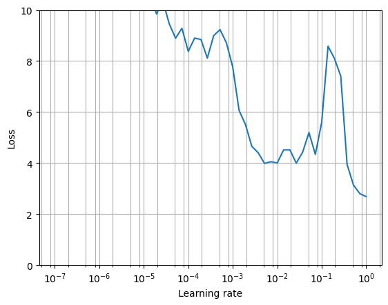

```python
# https://stackoverflow.com/questions/44078409/matplotlib-semi-log-plot-minor-tick-marks-are-gone-when-range-is-large/44079725#44079725
def plot_lrs_losses(lrs, losses):
    import matplotlib.ticker
    fig, ax=plt.subplots()
    ax.semilogx(lrs, losses)
    ax.set_ylim([0, 10.])
    ax.grid(True, which="both")
    locmaj = matplotlib.ticker.LogLocator(base=10,numticks=12)
    ax.xaxis.set_major_locator(locmaj)
    locmin = matplotlib.ticker.LogLocator(base=10.0,subs=(0.1,0.2,0.5, 0.8),numticks=12)
    ax.xaxis.set_minor_locator(locmin)
    ax.xaxis.set_minor_formatter(matplotlib.ticker.NullFormatter())
    ax.set_xlabel('Learning rate')
    ax.set_ylabel('Loss')
    plt.show()
    return
plot_lrs_losses(lrs, losses)
```

Here is the plot for AdamW optimizer with exampleCNN

```
plot_lrs_losses(lrs, losses)
```

[figure not shown]

And for SGD

[figure not shown]

A good value here would be 1e-3 for AdamW and 3e-3 for SGD with momentum.

We will use tensorboard for plotting training and validation statistics. It works as follows: the `writer` object writes logs in a specific format as training goes on. In a separate console window, run

```
tensorboard --logdir=runs --port=6006
```

And open [localhost:6006](http://localhost:6006/) in a separate browser window.

To add a value to tensorboard, one needs to use function add_scalar. For detailed reference see https://pytorch.org/docs/stable/tensorboard.html

```
writer.add_scalar("Loss/val", loss.item(), epoch_idx)
```

If you are running on Google Colab, you can open tensorboard in the cell:

```
%load_ext tensorboard
%tensorboard --logdir runs
```

```python
from torch.utils.tensorboard import SummaryWriter
```

```python
# remove any data from previous runs for clean tensorboard
!rm -rf runs/*
```

```python
# FOR COLAB: uncomment and run the following code every time you are starting the session.
# You can monitor the training here
%load_ext tensorboard
%tensorboard --logdir runs
```

```
Output hidden; open in https://colab.research.google.com to view.
```

```python
from cnn_training import *
from cnn_training import train_and_val_single_epoch
from torch.utils.tensorboard import SummaryWriter

model = SimpleCNN_improved(10)
# model = SimpleCNN_orig(10)
model.features.apply(weight_init)
model.clf.apply(weight_init)
loss_fn = nn.CrossEntropyLoss()
cuda_device = torch.device('cuda') if torch.cuda.is_available() else torch.device('cpu')

#Comment is a name for graph (see screenshot below)
#writer = SummaryWriter(comment="AdamW_no_scheduler")
writer = SummaryWriter(comment="SGD_no_scheduler")

# opt = torch.optim.AdamW(model.parameters(),lr=1e-3, weight_decay=1e-4, eps=1e-2)
opt = torch.optim.SGD(model.parameters(),lr=3e-3, weight_decay=1e-4, momentum=0.9)

for ep in range(3):
    t=time()
    model = train_and_val_single_epoch(model, train_dl, val_dl, opt, loss_fn, ep,
                                       writer=writer,
                                       device = cuda_device, additional_params={"with_acc": True})
    el = time() - t
    print (f"Train epoch in {el:.1f} sec")
```

```
Starting validation
```

```
init accuracy: 8.59% | init loss: 292.87
```

```
Epoch: 0 	 loss: 2.100
Starting validation
```

```
accuracy: 36.61% | loss: 227.23

Train epoch in 13.4 sec
```

```
Epoch: 1 	 loss: 3.208
Starting validation
```

```
accuracy: 35.72% | loss: 236.64

Train epoch in 10.1 sec
```

```
Epoch: 2 	 loss: 2.384
Starting validation
```

```
accuracy: 39.77% | loss: 217.73

Train epoch in 10.0 sec
```

Screenshot from tensorboard for the SGD

[figure not shown]

Screenshot from tensorboard for the AdamW

[figure not shown]

A good idea would be to use a learning rate scheduler i.e. not keeping the learning rate constant, but changing it on the fly. See the different learning rate schedules example (from [Systematic Evaluation of Convolution Neural Network Advances on the ImageNet](https://arxiv.org/pdf/1606.02228) paper).

[figure not shown]

Lets compare no-schedule (above) with one-cycle. Good schedules to try will be one-cycle policy, step-policy, linear policy. See an example here: https://pytorch.org/docs/stable/optim.html#how-to-adjust-learning-rate

```python
# load updated version of cnn_training.py
!cp -r "/content/drive/MyDrive/Colab Notebooks/MPV/CNN/cnn_training.py"         "/content/"
```

```python
from torch.optim.lr_scheduler import OneCycleLR
from cnn_training import *
loss_fn = nn.CrossEntropyLoss()
#Re-init the model
load_my_weights = True
not_so_simple = False
cuda_device = torch.device('cuda') if torch.cuda.is_available() else torch.device('cpu')

# vgg16 has first_stride = 1, vgg16light has first_stride = 2
first_stride = 1
model = VGG16(10, first_stride) if not_so_simple else SimpleCNN_improved(10)

if load_my_weights:
    # load saved weights from previous trainings
    #!cp -r "/content/drive/MyDrive/Colab Notebooks/MPV/CNN/weights_vgg16light.pts"  "/content/"
    !cp -r "/content/drive/MyDrive/Colab Notebooks/MPV/CNN/weights_Simproved_v2.pts"  "/content/"
    model.load_state_dict(torch.load('weights_Simproved_v2.pts'))
else:
    model.features.apply(weight_init)
    model.clf.apply(weight_init)
```

```python
# TRAINING RESULTS of SimpleCNN_improved version 1, do NOT run
n_epochs = 50

# writer = SummaryWriter(comment="AdamW_OneCycleSched")
writer = SummaryWriter(comment="SGD_OneCycleSched")

opt1 = torch.optim.AdamW(model.parameters(),lr=1e-3, weight_decay=1e-4, eps=1e-2)
opt2 = torch.optim.SGD(model.parameters(),lr=3e-3, weight_decay=1e-4, momentum=0.9)
#lr_sched = OneCycleLR(opt2, max_lr=3e-3, steps_per_epoch=len(train_dl), epochs=n_epochs)
lr_sched = None

for ep in range(n_epochs):
    t=time()
    model = train_and_val_single_epoch(model, train_dl, val_dl, opt2, loss_fn, ep, lr_sched, writer=writer,
                                      device = cuda_device, additional_params={"with_acc": True})
    el = time() -t
    # print (f"Train epoch in {el:.1f} sec")
```

```
Starting validation
```

```
init accuracy: 10.09% | init loss: 296.05
```

```
Epoch: 0 	 loss: 2.087
Starting validation
```

```
accuracy: 39.90% | loss: 226.95
```

```
Epoch: 1 	 loss: 3.255
Starting validation
```

```
accuracy: 34.11% | loss: 250.49
```

```
Epoch: 2 	 loss: 2.447
Starting validation
```

```
accuracy: 41.71% | loss: 235.24
```

```
Epoch: 3 	 loss: 2.258
Starting validation
```

```
accuracy: 48.31% | loss: 193.45
```

```
Epoch: 4 	 loss: 2.066
Starting validation
```

```
accuracy: 48.79% | loss: 195.12
```

```
Epoch: 5 	 loss: 1.988
Starting validation
```

```
accuracy: 53.30% | loss: 179.44
```

```
Epoch: 6 	 loss: 1.904
Starting validation
```

```
accuracy: 55.08% | loss: 177.32
```

```
Epoch: 7 	 loss: 1.803
Starting validation
```

```
accuracy: 58.73% | loss: 160.81
```

```
Epoch: 8 	 loss: 1.738
Starting validation
```

```
accuracy: 60.66% | loss: 151.25
```

```
Epoch: 9 	 loss: 1.715
Starting validation
```

```
accuracy: 59.77% | loss: 159.29
```

```
Epoch: 10 	 loss: 1.627
Starting validation
```

```
accuracy: 62.09% | loss: 153.16
```

```
Epoch: 11 	 loss: 1.562
Starting validation
```

```
accuracy: 62.90% | loss: 141.75
```

```
Epoch: 12 	 loss: 1.498
Starting validation
```

```
accuracy: 63.54% | loss: 146.14
```

```
Epoch: 13 	 loss: 1.468
Starting validation
```

```
accuracy: 61.04% | loss: 148.96
```

```
Epoch: 14 	 loss: 1.427
Starting validation
```

```
accuracy: 63.90% | loss: 140.70
```

```
Epoch: 15 	 loss: 1.389
Starting validation
```

```
accuracy: 64.69% | loss: 140.41
```

```
Epoch: 16 	 loss: 1.357
Starting validation
```

```
accuracy: 64.38% | loss: 140.72
```

```
Epoch: 17 	 loss: 1.344
Starting validation
```

```
accuracy: 66.60% | loss: 126.58
```

```
Epoch: 18 	 loss: 1.279
Starting validation
```

```
accuracy: 66.78% | loss: 129.28
```

```
Epoch: 19 	 loss: 1.293
Starting validation
```

```
accuracy: 68.20% | loss: 122.61
```

```
Epoch: 20 	 loss: 1.268
Starting validation
```

```
accuracy: 67.64% | loss: 126.17
```

```
Epoch: 21 	 loss: 1.228
Starting validation
```

```
accuracy: 69.68% | loss: 116.45
```

```
Epoch: 22 	 loss: 1.194
Starting validation
```

```
accuracy: 68.00% | loss: 124.73
```

```
Epoch: 23 	 loss: 1.225
Starting validation
```

```
accuracy: 69.53% | loss: 121.16
```

```
Epoch: 24 	 loss: 1.146
Starting validation
```

```
accuracy: 70.90% | loss: 112.96
```

```
Epoch: 25 	 loss: 1.129
Starting validation
```

```
accuracy: 68.43% | loss: 126.85
```

```
Epoch: 26 	 loss: 1.147
Starting validation
```

```
accuracy: 72.41% | loss: 109.43
```

```
Epoch: 27 	 loss: 1.119
Starting validation
```

```
accuracy: 71.34% | loss: 113.37
```

```
Epoch: 28 	 loss: 1.072
Starting validation
```

```
accuracy: 70.62% | loss: 113.32
```

```
Epoch: 29 	 loss: 1.060
Starting validation
```

```
accuracy: 71.95% | loss: 110.43
```

```
Epoch: 30 	 loss: 1.050
Starting validation
```

```
accuracy: 71.21% | loss: 112.90
```

```
Epoch: 31 	 loss: 1.024
Starting validation
```

```
accuracy: 71.57% | loss: 109.26
```

```
Epoch: 32 	 loss: 1.014
Starting validation
```

```
accuracy: 71.92% | loss: 111.99
```

```
Epoch: 33 	 loss: 0.999
Starting validation
```

```
accuracy: 72.82% | loss: 106.89
```

```
Epoch: 34 	 loss: 0.979
Starting validation
```

```
accuracy: 74.14% | loss: 99.74
```

```
Epoch: 35 	 loss: 1.019
Starting validation
```

```
accuracy: 72.43% | loss: 105.49
```

```
Epoch: 36 	 loss: 0.973
Starting validation
```

```
accuracy: 74.85% | loss: 99.67
```

```
Epoch: 37 	 loss: 0.956
Starting validation
```

```
accuracy: 74.42% | loss: 100.27
```

```
Epoch: 38 	 loss: 0.955
Starting validation
```

```
accuracy: 73.30% | loss: 101.13
```

```
Epoch: 39 	 loss: 0.927
Starting validation
```

```
accuracy: 74.52% | loss: 98.67
```

```
Epoch: 40 	 loss: 0.895
Starting validation
```

```
accuracy: 74.52% | loss: 100.41
```

```
Epoch: 41 	 loss: 0.902
Starting validation
```

```
accuracy: 73.43% | loss: 103.64
```

```
Epoch: 42 	 loss: 0.910
Starting validation
```

```
accuracy: 72.31% | loss: 107.20
```

```
Epoch: 43 	 loss: 0.875
Starting validation
```

```
accuracy: 73.50% | loss: 105.84
```

```
Epoch: 44 	 loss: 0.880
Starting validation
```

```
accuracy: 75.87% | loss: 95.12
```

```
Epoch: 45 	 loss: 0.863
Starting validation
```

```
accuracy: 76.18% | loss: 94.92
```

```
Epoch: 46 	 loss: 0.868
Starting validation
```

```
accuracy: 74.52% | loss: 102.65
```

```
Epoch: 47 	 loss: 0.860
Starting validation
```

```
accuracy: 75.49% | loss: 95.49
```

```
Epoch: 48 	 loss: 0.827
Starting validation
```

```
accuracy: 76.82% | loss: 95.43
```

```
Epoch: 49 	 loss: 0.855
Starting validation
```

```
accuracy: 75.92% | loss: 94.46
```

```python
# TRAINING RESULTS of SimpleCNN_improved version 2, do NOT run
# additional 30 epochs on top of 50 of SimpleCNN_v2 (3rd run)
n_epochs = 30

# writer = SummaryWriter(comment="AdamW_OneCycleSched")
writer = SummaryWriter(comment="SGD_OneCycleSched")

opt1 = torch.optim.AdamW(model.parameters(),lr=1e-3, weight_decay=1e-4, eps=1e-2)
opt2 = torch.optim.SGD(model.parameters(),lr=3e-3, weight_decay=1e-4, momentum=0.9)
lr_sched = OneCycleLR(opt2, max_lr=6e-3, steps_per_epoch=len(train_dl), epochs=n_epochs)
# lr_sched = None

for ep in range(n_epochs):
    t=time()
    model = train_and_val_single_epoch(model, train_dl, val_dl, opt2, loss_fn, ep, lr_sched, writer=writer,
                                      device = cuda_device, additional_params={"with_acc": True})
    el = time() -t
    # print (f"Train epoch in {el:.1f} sec")
```

```
Starting validation
```

```
init accuracy: 78.85% | init loss: 85.26
```

```
Epoch: 0 	 loss: 0.562
Starting validation
```

```
accuracy: 78.24% | loss: 88.84
```

```
Epoch: 1 	 loss: 0.603
Starting validation
```

```
accuracy: 78.90% | loss: 90.35
```

```
Epoch: 2 	 loss: 0.625
Starting validation
```

```
accuracy: 78.80% | loss: 88.05
```

```
Epoch: 3 	 loss: 0.604
Starting validation
```

```
accuracy: 78.80% | loss: 86.47
```

```
Epoch: 4 	 loss: 0.612
Starting validation
```

```
accuracy: 79.21% | loss: 87.36
```

```
Epoch: 5 	 loss: 0.589
Starting validation
```

```
accuracy: 79.21% | loss: 88.62
```

```
Epoch: 6 	 loss: 0.572
Starting validation
```

```
accuracy: 78.57% | loss: 89.05
```

```
Epoch: 7 	 loss: 0.612
Starting validation
```

```
accuracy: 78.42% | loss: 88.15
```

```
Epoch: 8 	 loss: 0.598
Starting validation
```

```
accuracy: 79.11% | loss: 84.55
```

```
Epoch: 9 	 loss: 0.604
Starting validation
```

```
accuracy: 78.75% | loss: 87.03
```

```
Epoch: 10 	 loss: 0.598
Starting validation
```

```
accuracy: 78.85% | loss: 91.17
```

```
Epoch: 11 	 loss: 0.604
Starting validation
```

```
accuracy: 79.39% | loss: 88.95
```

```
Epoch: 12 	 loss: 0.597
Starting validation
```

```
accuracy: 78.73% | loss: 87.70
```

```
Epoch: 13 	 loss: 0.595
Starting validation
```

```
accuracy: 79.08% | loss: 86.82
```

```
Epoch: 14 	 loss: 0.589
Starting validation
```

```
accuracy: 78.60% | loss: 88.16
```

```
Epoch: 15 	 loss: 0.581
Starting validation
```

```
accuracy: 79.39% | loss: 86.75
```

```
Epoch: 16 	 loss: 0.588
Starting validation
```

```
accuracy: 78.75% | loss: 87.52
```

```
Epoch: 17 	 loss: 0.595
Starting validation
```

```
accuracy: 79.41% | loss: 85.87
```

```
Epoch: 18 	 loss: 0.571
Starting validation
```

```
accuracy: 79.06% | loss: 87.71
```

```
Epoch: 19 	 loss: 0.567
Starting validation
```

```
accuracy: 79.39% | loss: 86.85
```

```
Epoch: 20 	 loss: 0.588
Starting validation
```

```
accuracy: 78.90% | loss: 89.63
```

```
Epoch: 21 	 loss: 0.575
Starting validation
```

```
accuracy: 79.18% | loss: 86.91
```

```
Epoch: 22 	 loss: 0.583
Starting validation
```

```
accuracy: 78.68% | loss: 90.56
```

```
Epoch: 23 	 loss: 0.571
Starting validation
```

```
accuracy: 79.39% | loss: 86.88
```

```
Epoch: 24 	 loss: 0.571
Starting validation
```

```
accuracy: 78.70% | loss: 88.85
```

```
Epoch: 25 	 loss: 0.577
Starting validation
```

```
accuracy: 79.52% | loss: 87.20
```

```
Epoch: 26 	 loss: 0.556
Starting validation
```

```
accuracy: 78.93% | loss: 87.84
```

```
Epoch: 27 	 loss: 0.568
Starting validation
```

```
accuracy: 79.21% | loss: 88.21
```

```
Epoch: 28 	 loss: 0.570
Starting validation
```

```
accuracy: 79.34% | loss: 87.05
```

```
Epoch: 29 	 loss: 0.558
Starting validation
```

```
accuracy: 79.18% | loss: 87.15
```

```python
# additional TRAINING with 512x512 dataset resolution
n_epochs = 10

# writer = SummaryWriter(comment="AdamW_OneCycleSched")
writer = SummaryWriter(comment="SGD_OneCycleSched")

opt1 = torch.optim.AdamW(model.parameters(),lr=1e-3, weight_decay=1e-4, eps=1e-2)
opt2 = torch.optim.SGD(model.parameters(),lr=3e-6, weight_decay=1e-4, momentum=0.9)
lr_sched = OneCycleLR(opt2, max_lr=3e-6, steps_per_epoch=len(train_dl), epochs=n_epochs)
#lr_sched = None

for ep in range(n_epochs):
    t=time()
    model = train_and_val_single_epoch(model, train_dl, val_dl, opt2, loss_fn, ep, lr_sched, writer=writer,
                                      device = cuda_device, additional_params={"with_acc": True})
    el = time() -t
    # print (f"Train epoch in {el:.1f} sec")
```

```
Starting validation
```

```
init accuracy: 82.75% | init loss: 65.93
```

```
Epoch: 0 	 loss: 0.509
Starting validation
```

```
accuracy: 82.70% | loss: 65.86
```

```
Epoch: 1 	 loss: 0.607
Starting validation
```

```
accuracy: 82.83% | loss: 65.08
```

```
Epoch: 2 	 loss: 0.604
Starting validation
```

```
accuracy: 82.83% | loss: 64.84
```

```
Epoch: 3 	 loss: 0.628
Starting validation
```

```
accuracy: 82.96% | loss: 65.06
```

```
Epoch: 4 	 loss: 0.609
Starting validation
```

```
accuracy: 82.96% | loss: 64.71
```

```
Epoch: 5 	 loss: 0.619
Starting validation
```

```
accuracy: 82.98% | loss: 65.07
```

```
Epoch: 6 	 loss: 0.601
Starting validation
```

```
accuracy: 82.75% | loss: 65.12
```

```
Epoch: 7 	 loss: 0.604
Starting validation
```

```
accuracy: 83.16% | loss: 64.58
```

```
Epoch: 8 	 loss: 0.615
Starting validation
```

```
accuracy: 82.88% | loss: 64.78
```

```
Epoch: 9 	 loss: 0.614
Starting validation
```

```
accuracy: 83.13% | loss: 64.35
```

```python
# save the learned weights of improved SimpleCNN
torch.save(model.state_dict(), 'weights_Simproved_v2.pts')
!cp -r "/content/weights_Simproved_v2.pts" "/content/drive/MyDrive/Colab Notebooks/MPV/CNN/"
```

```python
# save the learned weights of vgg16
torch.save(model.state_dict(), 'weights_vgg16.pts')
!cp -r "/content/weights_vgg16.pts" "/content/drive/MyDrive/Colab Notebooks/MPV/CNN/"
```

# Reference example

```
from torch.optim.lr_scheduler import OneCycleLR
from cnn_training import *
loss_fn = nn.CrossEntropyLoss()
#Re-init the model
model = SimpleCNN(10)
model.features.apply(weight_init)
model.clf.apply(weight_init)

writer = SummaryWriter(comment="AdamW_OneCycleSched")
opt1 = torch.optim.AdamW(model.parameters(),lr=1e-3, weight_decay=1e-4, eps=1e-2)
lr_sched = OneCycleLR(opt1, max_lr=3e-3, steps_per_epoch=len(train_dl), epochs=3)

for ep in range(3):
    t=time()
    model = train_and_val_single_epoch(model, train_dl, val_dl, opt1, loss_fn, ep, lr_sched, writer=writer)
    el = time() -t
    print (f"Train epoch in {el:.1f} sec")
```

[figure not shown]

Training for more epochs than 3 would lead to better results.

## Testing the network

Now we need to define a custom dataset to classify the folder with images. The `ImageFolder` is not suitable because it expects classes to be known. Your task is to define class `TestFolderDataset` and its methods `__init__`, `__getitem__` and `__len__`

```
WARNING:matplotlib.image:Clipping input data to the valid range for imshow with RGB data ([0..1] for floats or [0..255] for integers).
```

[figure not shown]

```python
from cnn_training import TestFolderDataset

test_tf = val_tf

test_data = TestFolderDataset('test_set',  transform=test_tf)

test_dl = torch.utils.data.DataLoader(test_data,
                                      batch_size= 32,
                                     shuffle = False,
                                     # num_workers = 4,
                                     drop_last=False)
plt.imshow(K.tensor_to_image(test_data[0]))
```

Now implement function `get_predictions`, which takes a model and dataset and outputs a list of class idxs

```python
from cnn_training import get_predictions
help(get_predictions)
```

```
Help on function get_predictions in module cnn_training:

get_predictions(model: torch.nn.modules.module.Module, test_dl: torch.utils.data.dataloader.DataLoader) -> torch.Tensor
    Function, which predicts class indexes for image in data loader.
    Ouput shape: [N, 1], where N is number of image in the dataset
```

Finally, lets create the submission (predictions on test set). **Make sure you are saving integer values, not floats**.

```python
def create_submission(preds, fnames):
    with open('submission.csv', 'w') as f:
        f.write('fname, label\n')
        for p, fn in zip(preds,fnames):
            f.write(f"{fn},{p.item()}\n")
    return
model = model.cpu()
preds = get_predictions(model, test_dl)
create_submission(preds, test_data.fnames)
```

Your task is to implement the functions above and get as good as possible accuracy on the test set. For local evaluation use validation set. If your accuracy is below 70%, you have done something wrong. Good luck!

```python
# save and backup all necessary files
!cp -r "/content/submission.csv"                                                 "/content/drive/MyDrive/Colab Notebooks/MPV/CNN/"
#!cp -r "/content/stats.pkl"                                                     "/content/drive/MyDrive/Colab Notebooks/MPV/CNN/"
#!cp -r "/content/cnn_training.py"                                               "/content/drive/MyDrive/Colab Notebooks/MPV/CNN/"
#!cp -r "/content/weights_vgg16light.pts"                                        "/content/drive/MyDrive/Colab Notebooks/MPV/CNN/"
```

```python
# convert this notebook to html and save
# !pip install nbconvert
!cp -r "/content/drive/MyDrive/Colab Notebooks/MPV/CNN/training-imagenette-CNN.ipynb" "/content/"
!jupyter nbconvert --to html /content/training-imagenette-CNN.ipynb --EmbedImagesPreprocessor.resize=small --output results.html
!cp -r "/content/results.html" "/content/drive/MyDrive/Colab Notebooks/MPV/CNN/"
```

```
[NbConvertApp] Converting notebook /content/training-imagenette-CNN.ipynb to html
[NbConvertApp] Writing 1397359 bytes to /content/results.html
```